# hw8

Sophia

2018年5月2日

## Load packages

```r
library('ggplot2') # visualization
library('ggthemes') # visualization
library('scales') # visualization
library('dplyr') # data manipulation
library('mice') # imputation
library('rpart')
library('randomForest') # classification algorithm
```

## 導入資料

```r
train <- read.csv('/Users/sophiasufas/Desktop/R/GitHub/DataScienceR/DataScienceR/week_8/hw8/train.csv', stringsAsFactors = F)
test  <- read.csv('/Users/sophiasufas/Desktop/R/GitHub/DataScienceR/DataScienceR/week_8/hw8/test.csv', stringsAsFactors = F)
test$Survived <- NA
train_test <- rbind(train,test)
```

## 處理資料中缺少的變量

看看資料集中有缺少什麼

```r
sapply(train_test,function(x) sum(is.na(x)))
```

```
## PassengerId    Survived      Pclass        Name         Sex         Age
##           0         418           0           0           0         263
##       SibSp       Parch      Ticket        Fare       Cabin    Embarked
##           0           0           0           1           0           0
```

```r
sapply(train_test,function(x) sum(x == ""))
```

```
## PassengerId    Survived      Pclass        Name         Sex         Age
##           0          NA           0           0           0          NA
##       SibSp       Parch      Ticket        Fare       Cabin    Embarked
##           0           0           0          NA        1014           2
```

由此可知，需要處理變量Age, Fare, Cabin, Embarked  
### Fare  
查看Fare缺失值的乘客基本信息

```r
faremiss <- which(is.na(train_test$Fare))
train_test[faremiss,]
```

```
##      PassengerId Survived Pclass               Name  Sex  Age SibSp Parch
## 1044        1044       NA      3 Storey, Mr. Thomas male 60.5     0     0
##      Ticket Fare Cabin Embarked
## 1044   3701   NA              S
```

對其他的乘客的票價進行視覺化來估計這位客人的票價(根據登船港口,船艙等級,年齡)

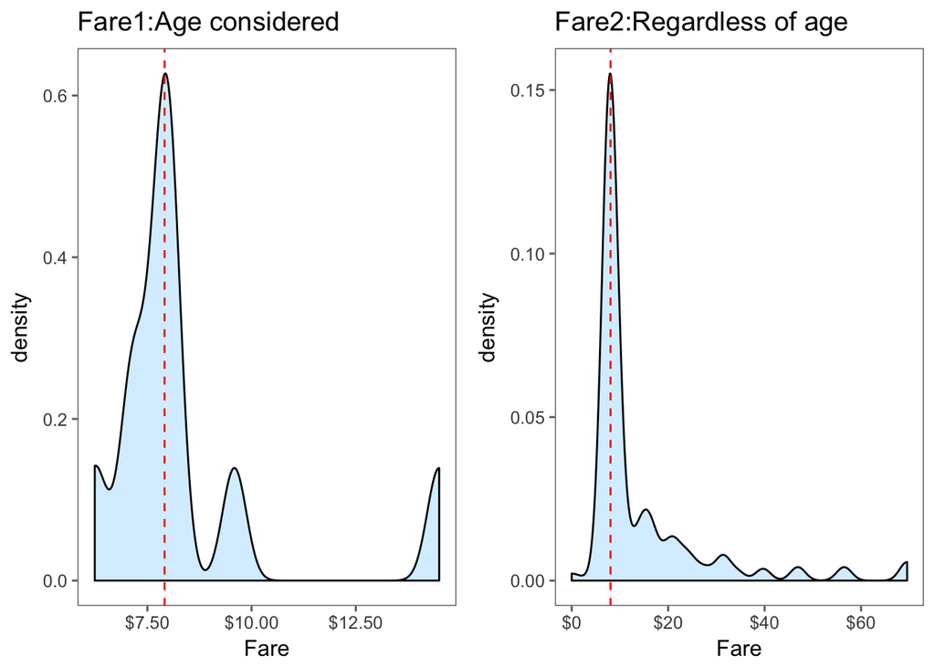

```r
Fareage <- ggplot(train_test[train_test$Pclass=='3' & train_test$Embarked=='S' & train_test$Age>=50 ,],
                aes( x=Fare )) +
  geom_density( fill = '#99d6ff',alpha=0.4 ) +
  geom_vline(aes(xintercept=median(Fare,na.rm=T)),colour='red',linetype='dashed') +
  ggtitle("Fare1:Age considered") +
  scale_x_continuous(labels=dollar_format()) +
  theme_few()
Fareothers <- ggplot(train_test[train_test$Pclass=='3' & train_test$Embarked=='S',],
                     aes( x=Fare )) +
  geom_density(fill = '#99d6ff',alpha=0.4 ) +
  geom_vline(aes(xintercept=median(Fare,na.rm=T)),colour='red',linetype='dashed' ) +
  ggtitle("Fare2:Regardless of age") +
  scale_x_continuous(labels=dollar_format()) +
  theme_few()
library(gridExtra)
grid.arrange(Fareage, Fareothers, ncol=2, nrow=1)
```

由此可推得票價大約落在“8”左右  
看具體數值來比較繪圖的精準度

```r
Fareage <- median(train_test[train_test$Pclass=='3' & train_test$Embarked=='S' & train_test$Age>=50 ,]$Fare,
                  na.rm = TRUE)
Fareage
```

```
## [1] 7.9125
```

```r
Fareothers <- median(train_test[train_test$Pclass=='3' & train_test$Embarked=='S' ,]$Fare,
                     na.rm = TRUE)
Fareothers
```

```
## [1] 8.05
```

依此看來價格也大約落在“8”左右，因此可以將缺失的fare賦值為8

```r
train_test$Fare[faremiss] <- 8.00
```

#### 觀察票價與存活率的相關程度

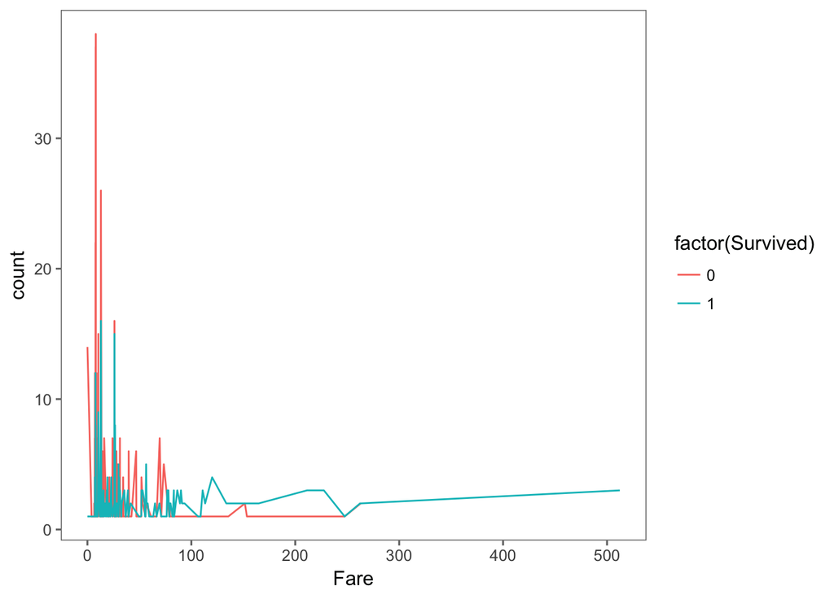

```r
ggplot(train_test[1:891,], aes(x = Fare, color = factor(Survived))) +
  geom_line(stat='count', position='dodge') +
  theme_few()
```

可以看出來票價對存活率的影響，fare越大，存活率越高

### Embarked

```r
embarkedmiss <- which(train_test$Embarked=="")
train_test[embarkedmiss,]
```

```
##     PassengerId Survived Pclass                                      Name
## 62           62        1      1                       Icard, Miss. Amelie
## 830         830        1      1 Stone, Mrs. George Nelson (Martha Evelyn)
##        Sex Age SibSp Parch Ticket Fare Cabin Embarked
## 62  female  38     0     0 113572   80   B28
## 830 female  62     0     0 113572   80   B28
```

```r
embark_fare <- train_test %>% #去除有缺值的行
  filter(PassengerId != 62 & PassengerId != 830)
```

藉由其他乘客的艙等、票價來推測這兩位乘客的登船港口  
視覺化登船港口與艙等和票價的關係

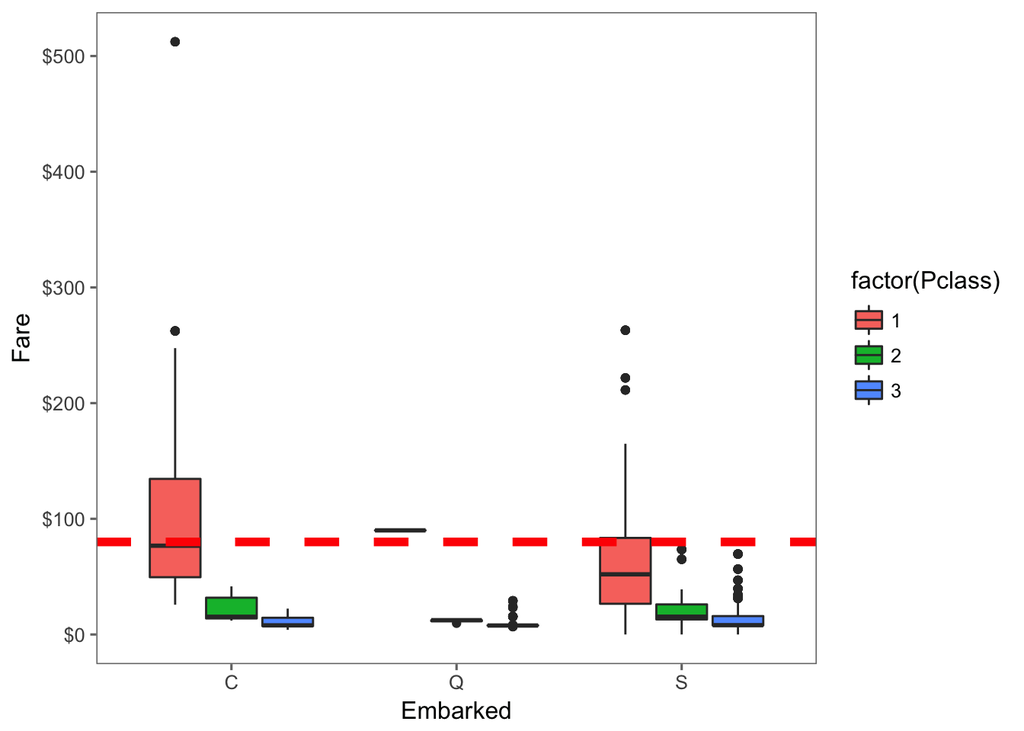

```r
ggplot(embark_fare, aes(x = Embarked, y = Fare, fill = factor(Pclass))) +
  geom_boxplot() +
  geom_hline(aes(yintercept=80),
             colour='red', linetype='dashed', lwd=2) +
  scale_y_continuous(labels=dollar_format()) +
  theme_few()
```

```r
train_test$Embarked[c(62, 830)] <- 'C'
train_test$Embarked <- factor(train_test$Embarked)
```

由圖可以看出c港乘客多搭乘頭等艙(Pclass:1), 而頭等艙的票價中位數大約是80,可以推斷Pclass為1且票價為＄80的這兩位乘客應該是於c港登船

## 新特徵-家庭規模

我認為在遇難時家庭通常會一起逃生，有可能同時遇難或倖存，如果不同家庭規模應該會與存活率相關，所以將SibSb和Parch合併為新的變量-familysize

```r
train_test$familysize <- train_test$SibSp + train_test$Parch +1
```

視覺化家庭規模與存活率的關係

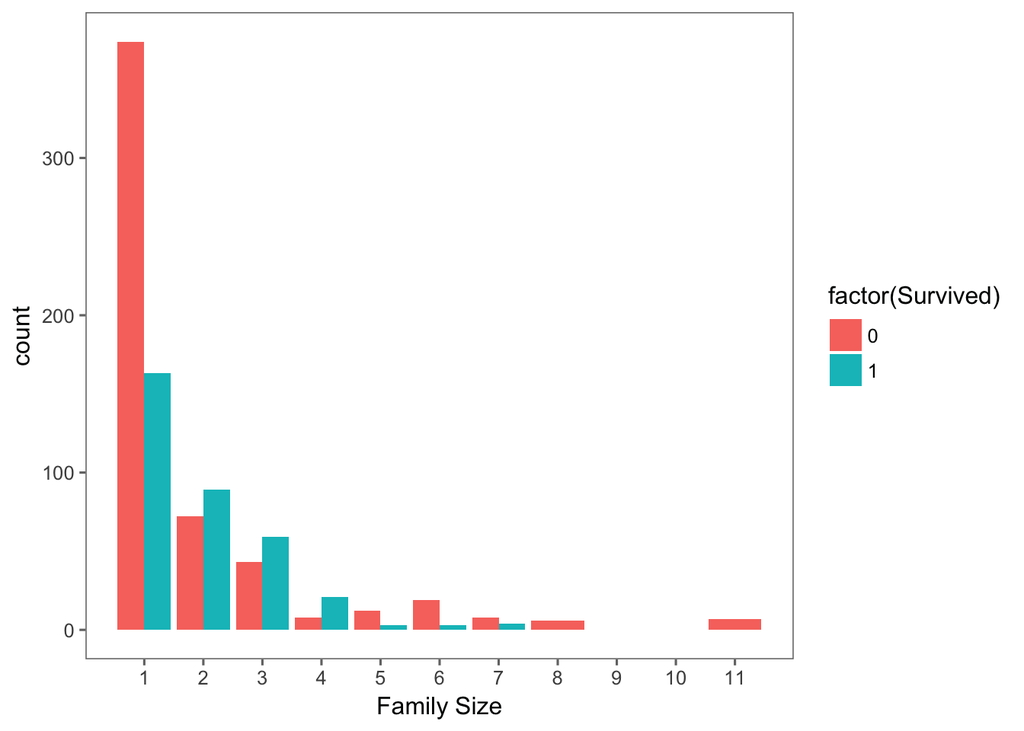

```r
ggplot(train_test[1:891,], aes(x = familysize, fill = factor(Survived))) +
  geom_bar(stat='count', position='dodge') +
  scale_x_continuous(breaks=c(1:11)) +
  labs(x = 'Family Size') +
  theme_few()
```

```r
train_test$familysize <- factor(train_test$familysize)
```

### 乘客頭銜

```r
train_test$Ptitle <- gsub('(.*, )|(\\..*)', '', train_test$Name)
##整理
rare_title <- c('Dona', 'Lady', 'the Countess','Capt', 'Col', 'Don',
                'Dr', 'Major', 'Rev', 'Sir', 'Jonkheer')
train_test$Ptitle[train_test$Ptitle == 'Mlle']        <- 'Miss'
train_test$Ptitle[train_test$Ptitle == 'Ms']          <- 'Miss'
train_test$Ptitle[train_test$Ptitle == 'Mme']         <- 'Mrs'
train_test$Ptitle[train_test$Ptitle %in% rare_title]  <- 'Rare Title'
train_test$Ptitle <- factor(train_test$Ptitle)
table(train_test$Sex, train_test$Ptitle)
```

```
##
##          Master Miss  Mr Mrs Rare Title
##   female      0  264   0 198          4
##   male       61    0 757   0         25
```

### Age

利用rpart套件來預測並填補Age的缺失值，由於加上家庭因素以及頭銜會使預測更加令人信服，所以這裡先處理一部分的變量之後才開始填補缺失值

```r
age_model <- rpart(Age~Pclass+Sex+SibSp+Parch+Fare+Embarked+Ptitle+familysize,
                   data=train_test[!is.na(train_test$Age),],method='anova')
train_test$Age[is.na(train_test$Age)] <- predict(age_model,train_test[is.na(train_test$Age),])
```

查看年齡、性別與存活率的關係

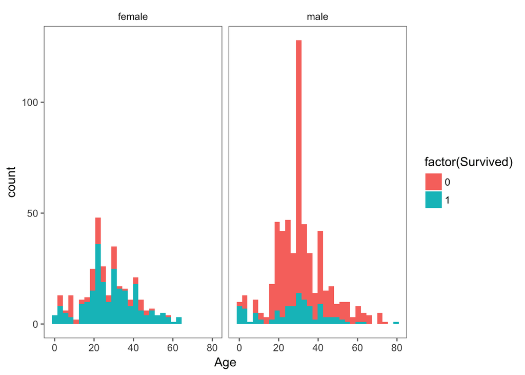

```r
ggplot(train_test[1:891,], aes(Age, fill = factor(Survived))) +
  geom_histogram() +
  facet_grid(.~Sex) +
  theme_few()
```

可以看得出來小孩的存活率是超過成年人，而且女性的存活率遠遠超過男性

## 新特徵-年齡段

將全部乘客年齡段為兒童、青年及成年人

```r
train_test$Age_group[train_test$Age <= 12] <- 'Child'
train_test$Age_group[train_test$Age > 12 & train_test$Age < 18] <- 'youth'
train_test$Age_group[train_test$Age >= 18] <- 'Adult'
train_test$Age_group  <- factor(train_test$Age_group)
```

視覺化統計結果

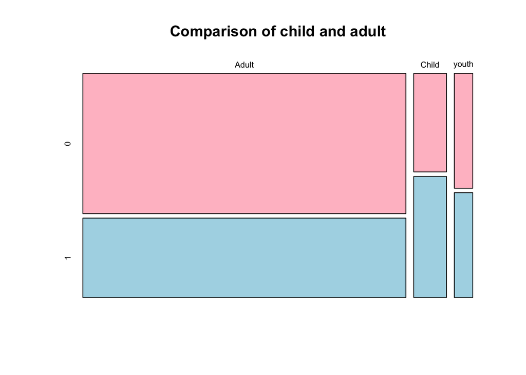

```r
mosaicplot(table(train_test$Age_group,
                 train_test$Survived),main='Comparison of child and adult',
           color=c("pink","lightblue"))
```

可以再次確認兒童的存活率是大於船上其他年齡段的

## 建模預測

```r
train_test$Sex <- as.factor(train_test$Sex)
train <- train_test[1:891,]
test <- train_test[892:1309,]
set.seed(754) #隨機種子
rf_model <- randomForest(factor(Survived) ~ Sex + Ptitle + Pclass + Embarked +
                           Age_group + Fare + familysize, data = train)
prediction <- predict(rf_model, test)
solution <- data.frame(PassengerID = test$PassengerId, Survived = prediction)
write.csv(solution, file = 'hw8.csv', row.names = F)
```